# ClassPrep5

Author

Jack Fay

```r
library(tidyverse)
library(here)
theme_set(theme_minimal())
hpi_df <- read_csv(here("Class Prep/data/hpi-tidy.csv"))
hpi_df
```

```
# A tibble: 151 × 11
   HPIRank Country     LifeExpectancy Wellbeing HappyLifeYears Footprint
     <dbl> <chr>                <dbl>     <dbl>          <dbl>     <dbl>
 1     109 Afghanistan           48.7      4.76           29.0     0.540
 2      18 Albania               76.9      5.27           48.8     1.81
 3      26 Algeria               73.1      5.24           46.2     1.65
 4     127 Angola                51.1      4.21           28.2     0.891
 5      17 Argentina             75.9      6.44           55.0     2.71
 6      53 Armenia               74.2      4.37           41.9     1.73
 7      76 Australia             81.9      7.41           65.5     6.68
 8      48 Austria               80.9      7.35           64.3     5.29
 9      80 Azerbaijan            70.7      4.22           39.1     1.97
10     146 Bahrain               75.1      4.55           43.5     6.65
# ℹ 141 more rows
# ℹ 5 more variables: HappyPlanetIndex <dbl>, Population <dbl>,
#   GDPcapita <dbl>, GovernanceRank <chr>, Region <chr>
```

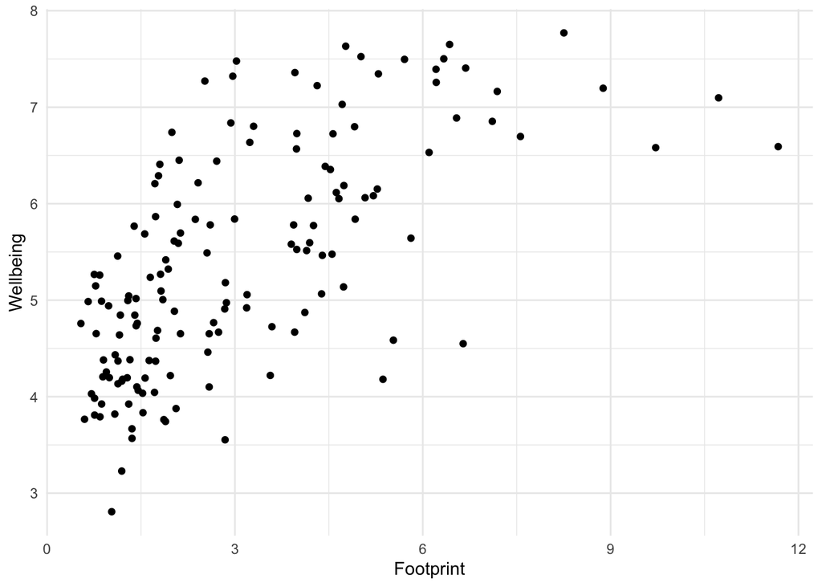

```r
ggplot(data = hpi_df, aes(x = Footprint, y = Wellbeing)) +
  geom_point()
```

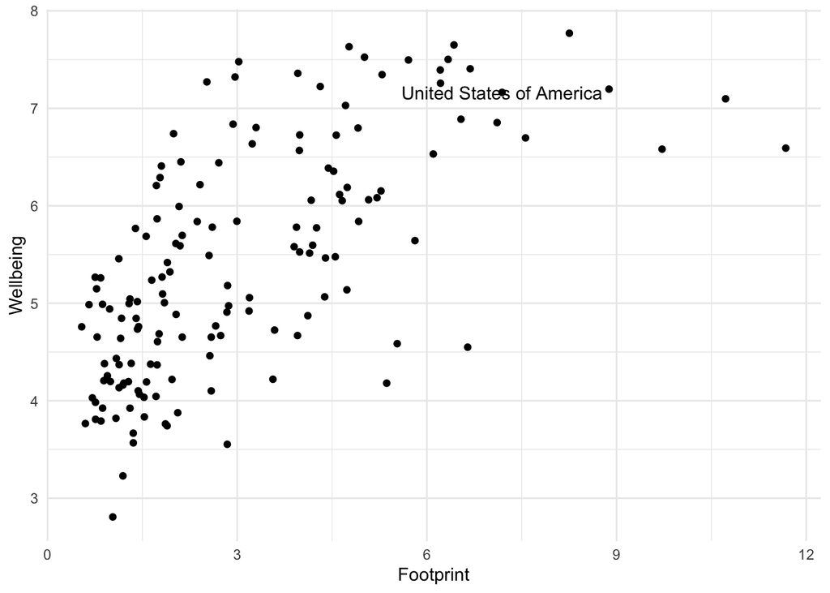

```r
hpi_us <- hpi_df |> filter(Country == "United States of America")

ggplot(data = hpi_df, aes(x = Footprint, y = Wellbeing)) +
  geom_point() +
  geom_text(data = hpi_us, aes(label = Country)) ## specify
```

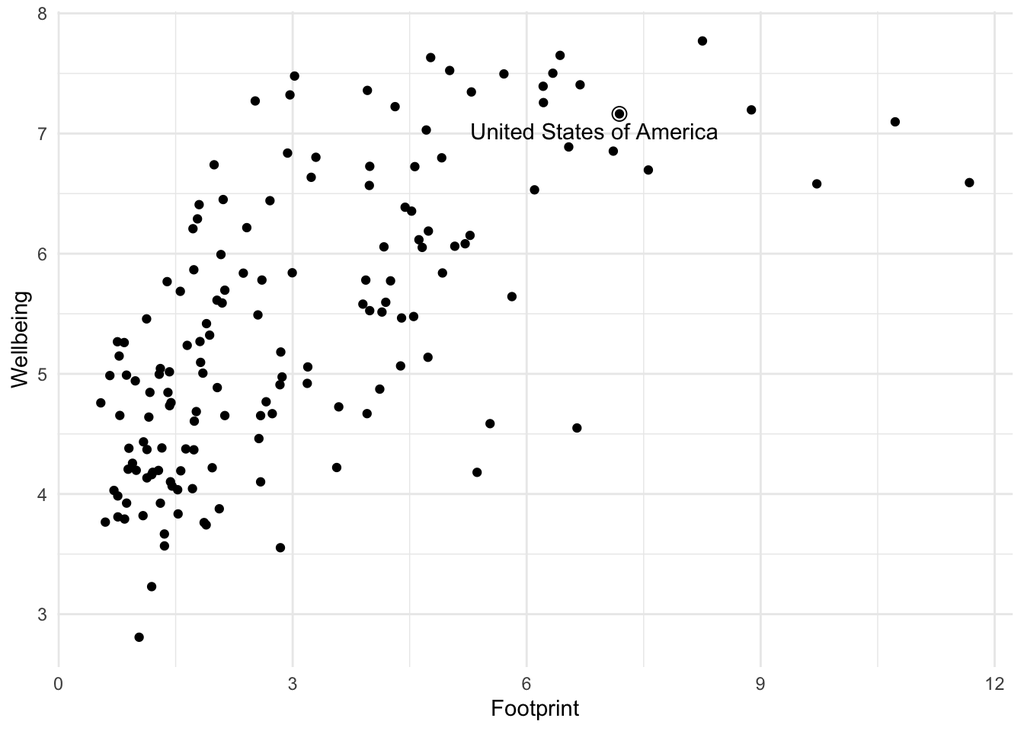

```r
library(ggrepel)
ggplot(data = hpi_df, aes(x = Footprint, y = Wellbeing)) +
  geom_point() +
  geom_text_repel(data = hpi_us, aes(label = Country)) +
  geom_point(data = hpi_us, size = 3, shape = 1) ## create a second point that is an open circle (shape = 1) with a larger size (size = 3) to surround the United States point on the scatterplot
```

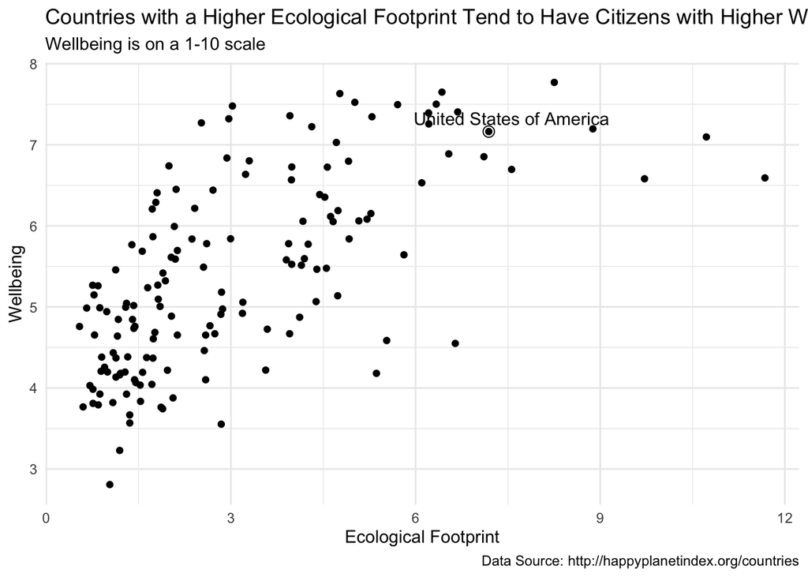

```r
ggplot(data = hpi_df, aes(x = Footprint, y = Wellbeing)) +
  geom_point() +
  geom_text_repel(data = hpi_us, aes(label = Country)) +
  geom_point(data = hpi_us, size = 3, shape = 1) +
  labs(title = "Countries with a Higher Ecological Footprint Tend to Have Citizens with Higher Wellbeing", ## add title
    subtitle = "Wellbeing is on a 1-10 scale", ## add subtitle (smaller text size than the title)
    caption = "Data Source: http://happyplanetindex.org/countries", ## add caption to the bottom of the figure
    x = "Ecological Footprint", ## change x axis label
    y = "Wellbeing") ## change y axis label
```

## Exercise 1: For each of the core dplyr functions mutate(), arrange(), select(), slice(), filter(), group_by(), and summarise(), write a one sentence summary of the overall purpose of the function.

mutate() - to create new variables, or edit existing variables in the data set

arrange() - to order cases based on the values of a variable

select() - to select or remove variables in the data set

slice() - to select certain intervals of cases, specific cases, and to omit certain cases. slice_max() and min allow you to find cases based on variable data

filter() - to select rows based on conditions of the variables

group_by()- to group cases together based on one or more variables

summarise() - creates a new data set where you can examine summary statistics for the existing or transformed data

## Exercise 2: Review mutate(). Create a new variable in hpi_df that is equal to Wellbeing / Footprint.

```r
hpi_df1 <- hpi_df%>%
  mutate(wellbeing_over_footprint = Wellbeing/Footprint)
```

## Exercise 3: Review mutate() and case_when(). Create a new variable in hpi_df that is equal to “80s” if LifeExp is in the 80’s, “70s” if LifeExp is in the 70s, and “Below 70” if LifeExp is less than 70.

```r
hpi_df2 <- hpi_df %>%
  mutate(Decade = case_when(
    LifeExpectancy >= 80 ~ "80s",
    LifeExpectancy >= 70 ~ "70s",
    TRUE ~ "Below 70"))
```

## Exercise 4. Review arrange(). Sort the hpi_df data so that the country with the highest LifeExp is in the first row and the country with the lowest LifeExp is in the last row.

```r
hpi_df3 <- hpi_df%>%
  arrange(desc(LifeExpectancy))
```

## Exercise 5. Review select(). Make a data frame from hpi_df that only has the variables Country and LifeExp.

```r
hpi_df4 <- hpi_df%>%
  select(Country, LifeExpectancy)
```

## Exercise 6. Review slice(). Make a data frame from hpi_df that only has the first 5 rows.

```r
hpi_df5 <- hpi_df%>%
  slice(1:5)
```

## Exercise 7. Review filter(). Make a data frame from hpi_df that only has countries in the “Western World” Region.

```r
hpi_df6 <- hpi_df%>%
  filter(Region == "Western World")
```

## Exercise 8. Review filter(). Make a data frame from hpi_df that only has countries with a LifeExp less than 55.

```r
hpi_df7 <- hpi_df%>%
  filter(LifeExpectancy < 55)
```

## Exercise 9. Review group_by() and summarise(). Make a table of the number of countries in each Region. (Hint: recall that the n() function is the counting function in dplyr).

```r
hpi_df8 <- hpi_df%>%
  group_by(Region)%>%
  summarise(total_countries = n())
```

## Exercise 10. Review group_by() and summarise(). Make a table with the maximum LifeExp in each Region.

```r
hpi_df9 <- hpi_df%>%
  group_by(Region)%>%
  summarise(highest_life_expectancy = max(LifeExpectancy))
```

Again, we will see non-dplyr functions as well throughout the course, but we will try to review them as they come along. As long as you have a solid dplyr base (and, of course a good ggplot2 base), you should be good to go!